# Graded Novelty Encoding Task - lab study analysis

The paradigm

-Familiarization phase Participants see 5 stimuli repeated 8 times each. Stimuli consist of a 3x3 grid, with 5 random shapes (circle,triangle,square) placed randomly (any 9 cells) with random color (red,blue,yellow,green,orange,purple).

-Study phase Participants see the 5 familiar stimuli 5 times each (25) and 50 novel stimuli. They have to judge if the current stimulus is one of the familiars. The novels differ to a differing degree from the familiars: there is 5x2 (two for each familiar) that is wholly different (diffarr). 5x2 that has the same placement of random shapes (sarr), 5x2 same arrangement and shapes (sarrsha), 5x2 same arrangement and colors (sarrcol) 5x2 same arrangement, shapes and colors (colors are randomized, thus, these are not the same as the familiars - sarrshacol).

-Test phase Participants see the novels from the study phase and 50 new stimuli (sarr - 10, sarrsha - 10, etc.). Participants have to signal if they have already seen the current stimulus or it is wholly new. They had the option to signal “maybe”, but were asked to do this in moderation (maybe resp <= 20). These responses have been added to correct responses.

# Participants

The online task has been started a total of 63 times.

We excluded some (0) runs as they missed more than 66 of 175 trials.

We also excluded 2 runs in which the participant produced less than 0.3 corrected recognition rate for familiars in the study phase.

We also excluded 0 participants as they overused “maybe” responses in the test phase (more than 25).

This left a total of 61 participants.

Maybe responses [mean(±sd)] : 13.7540984 ± 3.6635854

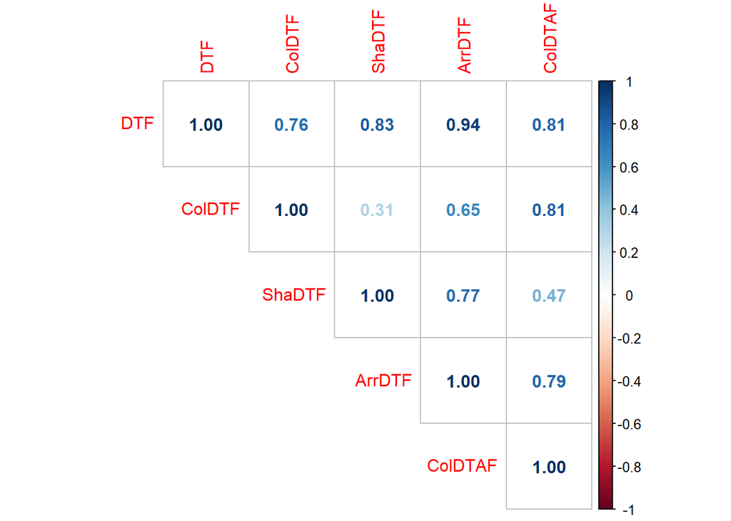

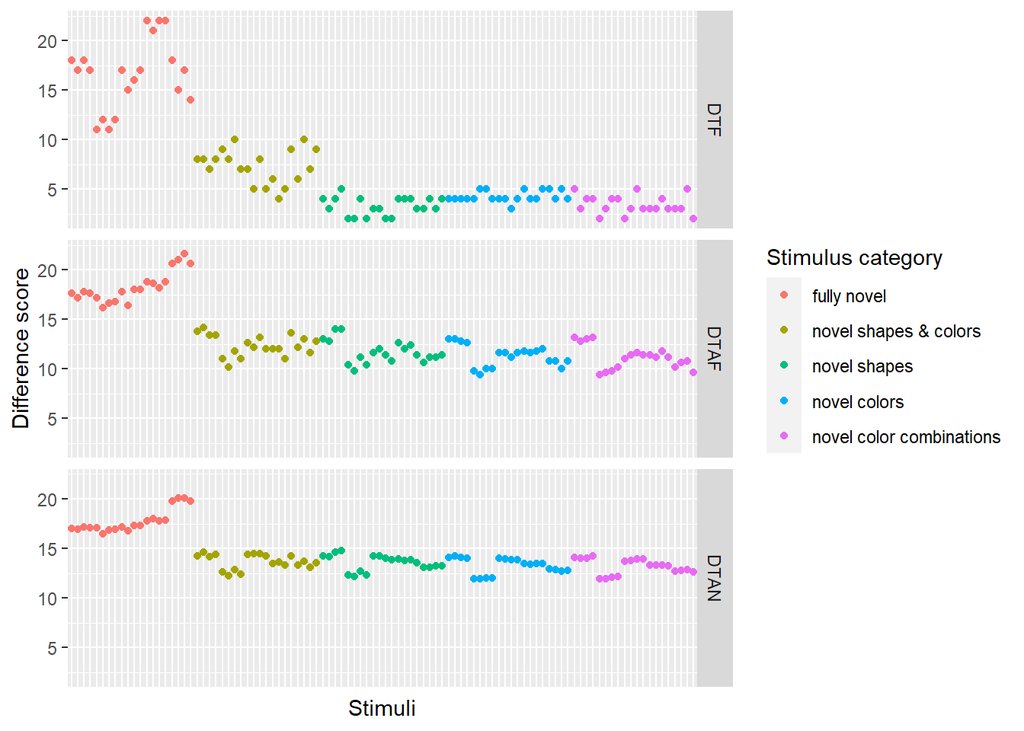

# Study phase:

During the study phase, the participants see familiar and novel items.

The participants produced a mean (±sd) recognition rate of 0.6268852 ± 0.103723 for familiar pictures.

The participants produced a mean (±sd) corrected recognition rate of 0.4980328 ± 0.1135902 for familiar pictures.

Uncorrected: The sample performed above chance levels, as a one sample t-test showed (t(60)=9.5543421, p = 1.1664958^{-13}, Cohen’s d = 1.2233082, 95% CI:0.6652286 - 1.7813877).

Corrected: The sample performed above chance levels, as a one sample t-test showed (t(60)=34.2438046, p = 4.3752454^{-41}, Cohen’s d = 4.3844699, 95% CI:3.4395667 - 5.3293731).

We use an ANOVA to see if there is a difference in correct rejection for the different novels.

```
## Anova Table (Type 3 tests)
##
## Response: N
##   Effect           df  MSE         F  ges p.value
## 1   type 3.94, 236.29 1.44 16.99 *** .172   <.001
## ---
## Signif. codes:  0 '***' 0.001 '**' 0.01 '*' 0.05 '+' 0.1 ' ' 1
##
## Sphericity correction method: GG
```

```
##  contrast             estimate    SE df t.ratio p.value
##  diffarr - sarr          0.574 0.211 60   2.720  0.0628
##  diffarr - sarrcol       0.803 0.209 60   3.846  0.0026
##  diffarr - sarrsha       1.738 0.212 60   8.214  <.0001
##  diffarr - sarrshacol    0.918 0.218 60   4.203  0.0008
##  sarr - sarrcol          0.230 0.216 60   1.062  0.8248
##  sarr - sarrsha          1.164 0.233 60   5.000  0.0001
##  sarr - sarrshacol       0.344 0.210 60   1.637  0.4799
##  sarrcol - sarrsha       0.934 0.218 60   4.289  0.0006
##  sarrcol - sarrshacol    0.115 0.218 60   0.526  0.9844
##  sarrsha - sarrshacol   -0.820 0.214 60  -3.837  0.0027
##
## P value adjustment: tukey method for comparing a family of 5 estimates
```

```
##  contrast  estimate    SE df t.ratio p.value
##  linear       -3.00 0.493 60  -6.091  <.0001
##  quadratic     2.08 0.538 60   3.868  0.0003
##  cubic         1.41 0.517 60   2.729  0.0083
##  quartic       3.51 1.230 60   2.852  0.0060
```

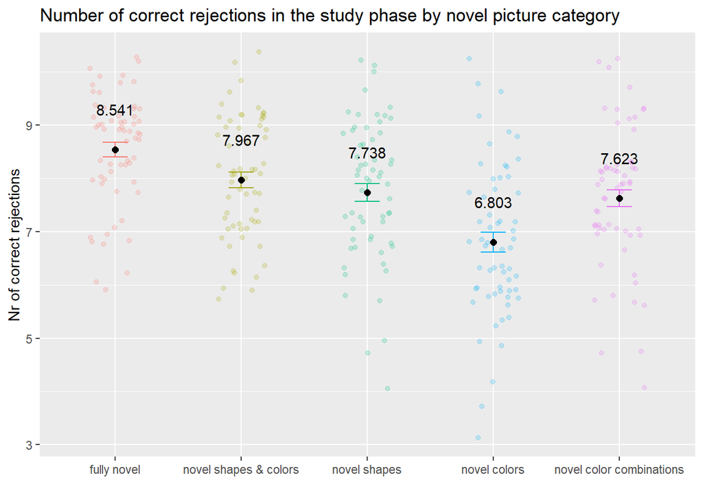

# Test phase:

Maybe responses (MEAN ± SD): 13.7540984 ± 3.6635854.

```
## [1] "A t-test to compare the number of old responses btwn old and new stim"
```

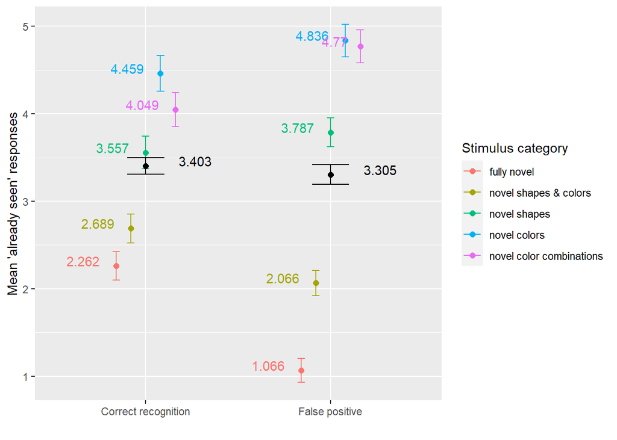

Results of the paired t-test: (t(304)=0.8284421, p = 0.4080701, Cohen’s d = 0.0539498, 95% CI:-0.0740345 - 0.181934).

Shapiro-Wilk is significant (p = 3.3957035^{-5}).

We used a Wilcoxon sgined-rank test. Z = -0.6320093, p = 0.2636904

## ANOVA - Corrected Recog

```
## Anova Table (Type 3 tests)
##
## Response: CorrRecog
##     Effect           df  MSE        F  ges p.value
## 1 neworder 3.83, 230.08 4.02 9.85 *** .116   <.001
## ---
## Signif. codes:  0 '***' 0.001 '**' 0.01 '*' 0.05 '+' 0.1 ' ' 1
##
## Sphericity correction method: GG
```

```
##  contrast estimate    SE df t.ratio p.value
##  A - B       0.574 0.308 60   1.864  0.3479
##  A - C       1.574 0.345 60   4.565  0.0002
##  A - D       1.426 0.342 60   4.176  0.0009
##  A - E       1.918 0.316 60   6.077  <.0001
##  B - C       1.000 0.373 60   2.684  0.0683
##  B - D       0.852 0.383 60   2.224  0.1850
##  B - E       1.344 0.354 60   3.793  0.0031
##  C - D      -0.148 0.390 60  -0.378  0.9955
##  C - E       0.344 0.367 60   0.937  0.8812
##  D - E       0.492 0.366 60   1.345  0.6644
##
## P value adjustment: tukey method for comparing a family of 5 estimates
```

```
##  contrast  estimate    SE df t.ratio p.value
##  linear      -4.689 0.757 60  -6.194  <.0001
##  quadratic    1.311 0.910 60   1.441  0.1549
##  cubic       -0.213 0.812 60  -0.262  0.7939
##  quartic     -3.361 2.213 60  -1.518  0.1342
```

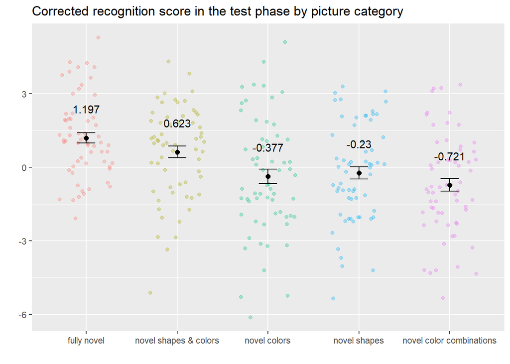

ANOVA (factor: TYPE (5 lvls)): (F[3.8347074,230.0824442] = 9.8520874, p = 3.5651147^{-7}, n2G = 0.1160667).

# Mixed models

The metrics

-DTF - Difference To corresponding Familiar picture All pictures are compared to a familiar. The number of differences between the three vectors of the pictures yields a difference score.

-DTAF - mean Difference To All Familiars We calculate the difference from all prototypes and take the mean for each picture in the set.

-DTN - mean Difference To All other Novels in the same category We calculate the differences between each pair of pictures and then take the mean of these differences (19 comparisons per stim).

## Study phase

```
## Generalized linear mixed model fit by maximum likelihood (Laplace
##   Approximation) [glmerMod]
##  Family: binomial  ( logit )
## Formula: st_corr ~ DTF + (1 | ID)
##    Data: stlmm
##
##      AIC      BIC   logLik deviance df.resid
##   5251.0   5270.3  -2622.5   5245.0     4572
##
## Scaled residuals:
##     Min      1Q  Median      3Q     Max
## -3.4427 -1.3720  0.5907  0.6677  0.7298
##
## Random effects:
##  Groups Name        Variance  Std.Dev.
##  ID     (Intercept) 0.0006229 0.02496
## Number of obs: 4575, groups:  ID, 61
##
## Fixed effects:
##             Estimate Std. Error z value Pr(>|z|)
## (Intercept) 0.635154   0.043006   14.77   <2e-16 ***
## DTF         0.083329   0.007743   10.76   <2e-16 ***
## ---
## Signif. codes:  0 '***' 0.001 '**' 0.01 '*' 0.05 '.' 0.1 ' ' 1
##
## Correlation of Fixed Effects:
##     (Intr)
## DTF -0.618
```

[output not shown]

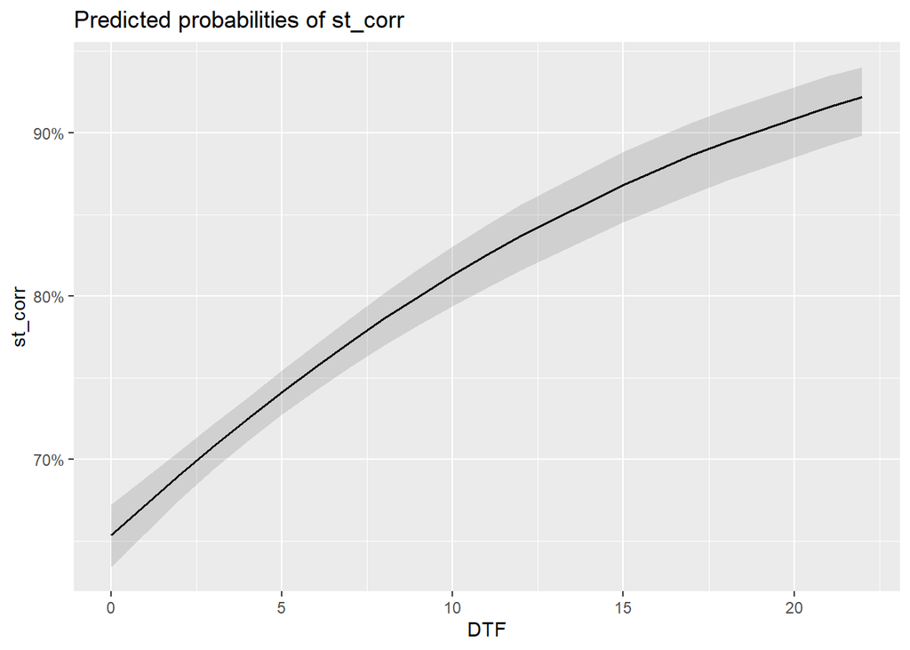

```
## Generalized linear mixed model fit by maximum likelihood (Laplace
##   Approximation) [glmerMod]
##  Family: binomial  ( logit )
## Formula: st_corr ~ DTAF + (1 | ID)
##    Data: stlmm
##
##      AIC      BIC   logLik deviance df.resid
##   5247.2   5266.5  -2620.6   5241.2     4572
##
## Scaled residuals:
##     Min      1Q  Median      3Q     Max
## -2.4167 -1.2669  0.5356  0.5843  0.7908
##
## Random effects:
##  Groups Name        Variance  Std.Dev.
##  ID     (Intercept) 0.0009262 0.03043
## Number of obs: 4575, groups:  ID, 61
##
## Fixed effects:
##             Estimate Std. Error z value Pr(>|z|)
## (Intercept) 0.477106   0.051229   9.313   <2e-16 ***
## DTAF        0.061116   0.005145  11.878   <2e-16 ***
## ---
## Signif. codes:  0 '***' 0.001 '**' 0.01 '*' 0.05 '.' 0.1 ' ' 1
##
## Correlation of Fixed Effects:
##      (Intr)
## DTAF -0.749
```

[output not shown]

```
## Data were 'prettified'. Consider using `terms="DTAF [all]"` to get smooth plots.
```

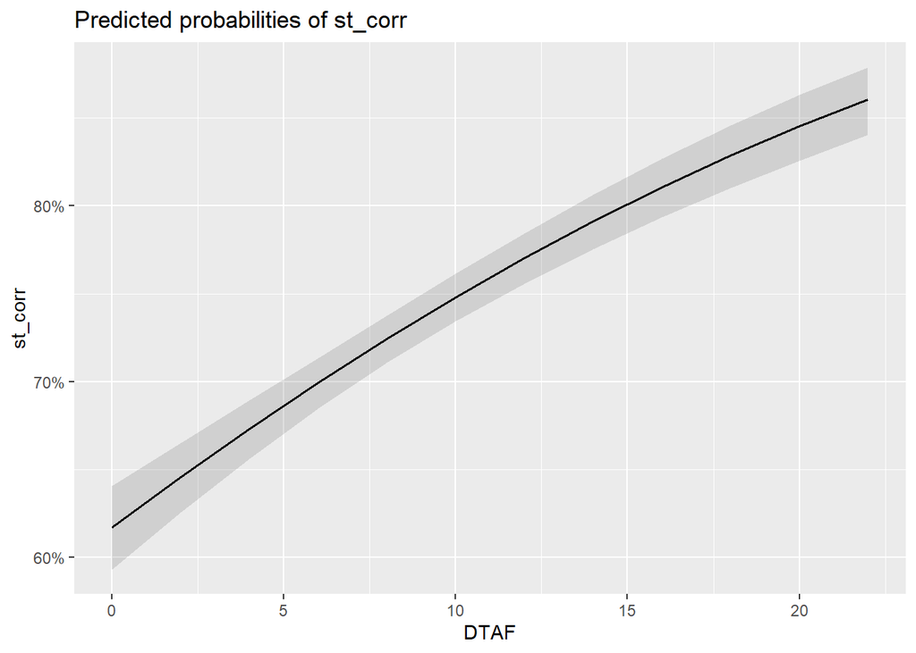

```
## Generalized linear mixed model fit by maximum likelihood (Laplace
##   Approximation) [glmerMod]
##  Family: binomial  ( logit )
## Formula: st_corr ~ DTAN + (1 | ID)
##    Data: stlmm
##
##      AIC      BIC   logLik deviance df.resid
##   5257.4   5276.7  -2625.7   5251.4     4572
##
## Scaled residuals:
##     Min      1Q  Median      3Q     Max
## -2.2158 -1.2693  0.5257  0.5790  0.7891
##
## Random effects:
##  Groups Name        Variance  Std.Dev.
##  ID     (Intercept) 0.0007874 0.02806
## Number of obs: 4575, groups:  ID, 61
##
## Fixed effects:
##             Estimate Std. Error z value Pr(>|z|)
## (Intercept) 0.480333   0.052048   9.229   <2e-16 ***
## DTAN        0.060765   0.005262  11.549   <2e-16 ***
## ---
## Signif. codes:  0 '***' 0.001 '**' 0.01 '*' 0.05 '.' 0.1 ' ' 1
##
## Correlation of Fixed Effects:
##      (Intr)
## DTAN -0.759
```

[output not shown]

```
## Data were 'prettified'. Consider using `terms="DTAN [all]"` to get smooth plots.
```

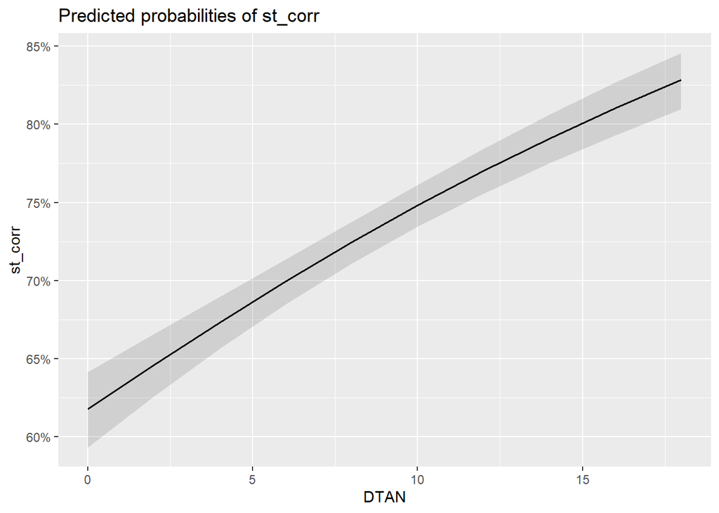

|  | st_corr |  |  |  | st_corr |  |  |  | st_corr |  |  |  |
| --- | --- | --- | --- | --- | --- | --- | --- | --- | --- | --- | --- | --- |
| Predictors | Log-Odds | std. Error | CI | p | Log-Odds | std. Error | CI | p | Log-Odds | std. Error | CI | p |
| (Intercept) | 0.64 | 0.04 | 0.55 – 0.72 | **<0.001** | 0.48 | 0.05 | 0.38 – 0.58 | **<0.001** | 0.48 | 0.05 | 0.38 – 0.58 | **<0.001** |
| DTF | 0.08 | 0.01 | 0.07 – 0.10 | **<0.001** |  |  |  |  |  |  |  |  |
| DTAF |  |  |  |  | 0.06 | 0.01 | 0.05 – 0.07 | **<0.001** |  |  |  |  |
| DTAN |  |  |  |  |  |  |  |  | 0.06 | 0.01 | 0.05 – 0.07 | **<0.001** |
| Random Effects |  |  |  |  |  |  |  |  |  |  |  |  |
| σ<sup>2</sup> | 3.29 |  |  |  | 3.29 |  |  |  | 3.29 |  |  |  |
| τ<sub>00</sub> | 0.00 <sub>ID</sub> |  |  |  | 0.00 <sub>ID</sub> |  |  |  | 0.00 <sub>ID</sub> |  |  |  |
| ICC | 0.00 |  |  |  | 0.00 |  |  |  | 0.00 |  |  |  |
| N | 61 <sub>ID</sub> |  |  |  | 61 <sub>ID</sub> |  |  |  | 61 <sub>ID</sub> |  |  |  |
| Observations | 4575 |  |  |  | 4575 |  |  |  | 4575 |  |  |  |
| Marginal R<sup>2</sup> / Conditional R<sup>2</sup> | 0.059 / 0.059 |  |  |  | 0.046 / 0.046 |  |  |  | 0.042 / 0.042 |  |  |  |
| AIC | 5250.996 |  |  |  | 5247.202 |  |  |  | 5257.371 |  |  |  |
| AICc | 5251.001 |  |  |  | 5247.207 |  |  |  | 5257.377 |  |  |  |

## Test phase

### Models #1 - without trial quality as random slope

Logistic mixed regression for the test phase. Does difference from prototypes or familiarity/novelty have an effect on correct categorization in the test phase?

```
## boundary (singular) fit: see ?isSingular
```

```
## Generalized linear mixed model fit by maximum likelihood (Laplace
##   Approximation) [glmerMod]
##  Family: binomial  ( logit )
## Formula: rt_resp ~ DTF * tq + (1 | ID)
##    Data: tdlmm
##
##      AIC      BIC   logLik deviance df.resid
##   6674.4   6707.2  -3332.2   6664.4     5256
##
## Scaled residuals:
##     Min      1Q  Median      3Q     Max
## -1.1254 -0.8785 -0.5505  1.0649  4.4664
##
## Random effects:
##  Groups Name        Variance Std.Dev.
##  ID     (Intercept) 0        0
## Number of obs: 5261, groups:  ID, 61
##
## Fixed effects:
##             Estimate Std. Error z value Pr(>|z|)
## (Intercept)  0.55919    0.07610   7.348 2.01e-13 ***
## DTF         -0.16147    0.01125 -14.347  < 2e-16 ***
## tqold       -0.55135    0.10052  -5.485 4.14e-08 ***
## DTF:tqold    0.09472    0.01395   6.788 1.14e-11 ***
## ---
## Signif. codes:  0 '***' 0.001 '**' 0.01 '*' 0.05 '.' 0.1 ' ' 1
##
## Correlation of Fixed Effects:
##           (Intr) DTF    tqold
## DTF       -0.832
## tqold     -0.757  0.630
## DTF:tqold  0.671 -0.807 -0.812
## optimizer (Nelder_Mead) convergence code: 0 (OK)
## boundary (singular) fit: see ?isSingular
```

[output not shown]

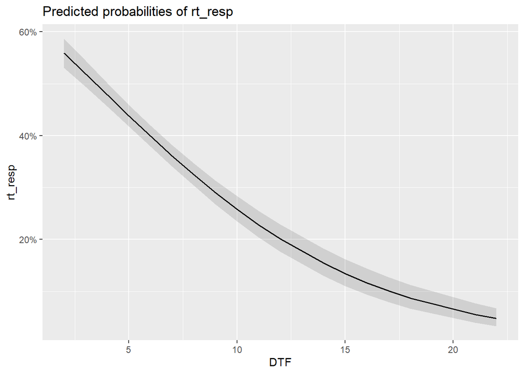

[output not shown]

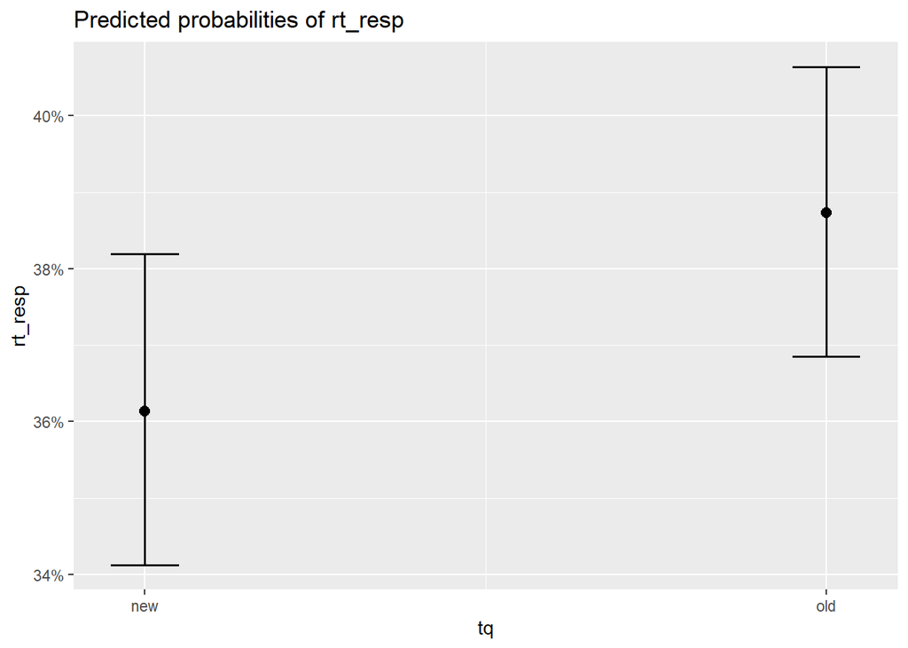

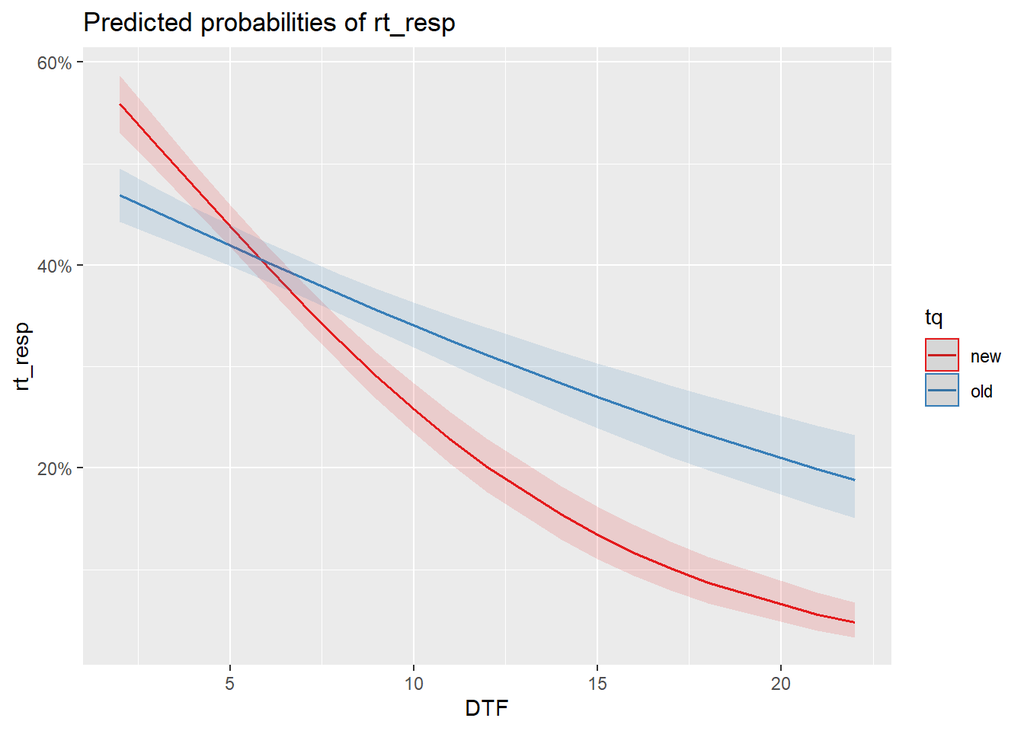

```
## boundary (singular) fit: see ?isSingular
```

```
## Generalized linear mixed model fit by maximum likelihood (Laplace
##   Approximation) [glmerMod]
##  Family: binomial  ( logit )
## Formula: rt_resp ~ DTAF * tq + (1 | ID)
##    Data: tdlmm
##
##      AIC      BIC   logLik deviance df.resid
##   6667.3   6700.1  -3328.6   6657.3     5256
##
## Scaled residuals:
##     Min      1Q  Median      3Q     Max
## -1.2129 -0.8684 -0.5451  1.0592  4.3827
##
## Random effects:
##  Groups Name        Variance  Std.Dev.
##  ID     (Intercept) 3.825e-13 6.185e-07
## Number of obs: 5261, groups:  ID, 61
##
## Fixed effects:
##             Estimate Std. Error z value Pr(>|z|)
## (Intercept)  3.05926    0.23683  12.917  < 2e-16 ***
## DTAF        -0.27845    0.01898 -14.670  < 2e-16 ***
## tqold       -1.82894    0.30661  -5.965 2.45e-09 ***
## DTAF:tqold   0.14847    0.02425   6.122 9.27e-10 ***
## ---
## Signif. codes:  0 '***' 0.001 '**' 0.01 '*' 0.05 '.' 0.1 ' ' 1
##
## Correlation of Fixed Effects:
##            (Intr) DTAF   tqold
## DTAF       -0.984
## tqold      -0.772  0.760
## DTAF:tqold  0.770 -0.783 -0.982
## optimizer (Nelder_Mead) convergence code: 0 (OK)
## boundary (singular) fit: see ?isSingular
```

[output not shown]

```
## Data were 'prettified'. Consider using `terms="DTAF [all]"` to get smooth plots.
```

[output not shown]

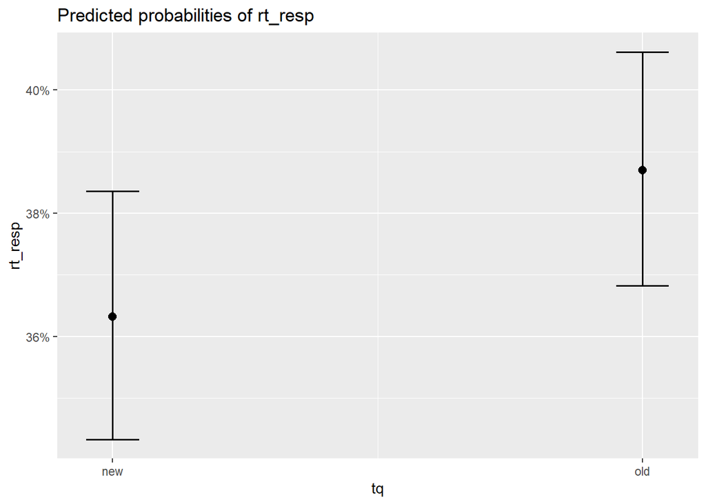

```
## Data were 'prettified'. Consider using `terms="DTAF [all]"` to get smooth plots.
```

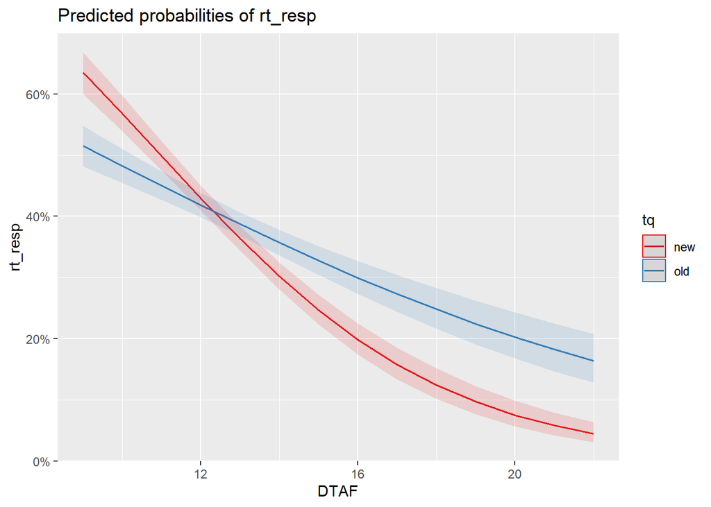

```
## boundary (singular) fit: see ?isSingular
```

```
## Generalized linear mixed model fit by maximum likelihood (Laplace
##   Approximation) [glmerMod]
##  Family: binomial  ( logit )
## Formula: rt_resp ~ DTAN * tq + (1 | ID)
##    Data: tdlmm
##
##      AIC      BIC   logLik deviance df.resid
##   6723.0   6755.8  -3356.5   6713.0     5256
##
## Scaled residuals:
##     Min      1Q  Median      3Q     Max
## -1.3072 -0.8224 -0.5540  1.0744  3.2089
##
## Random effects:
##  Groups Name        Variance Std.Dev.
##  ID     (Intercept) 0        0
## Number of obs: 5261, groups:  ID, 61
##
## Fixed effects:
##             Estimate Std. Error z value Pr(>|z|)
## (Intercept)  4.06359    0.31251  13.003  < 2e-16 ***
## DTAN        -0.35845    0.02483 -14.438  < 2e-16 ***
## tqold       -2.13286    0.42228  -5.051 4.40e-07 ***
## DTAN:tqold   0.17309    0.03331   5.197 2.02e-07 ***
## ---
## Signif. codes:  0 '***' 0.001 '**' 0.01 '*' 0.05 '.' 0.1 ' ' 1
##
## Correlation of Fixed Effects:
##            (Intr) DTAN   tqold
## DTAN       -0.991
## tqold      -0.740  0.733
## DTAN:tqold  0.738 -0.745 -0.990
## optimizer (Nelder_Mead) convergence code: 0 (OK)
## boundary (singular) fit: see ?isSingular
```

[output not shown]

```
## Data were 'prettified'. Consider using `terms="DTAN [all]"` to get smooth plots.
```

[output not shown]

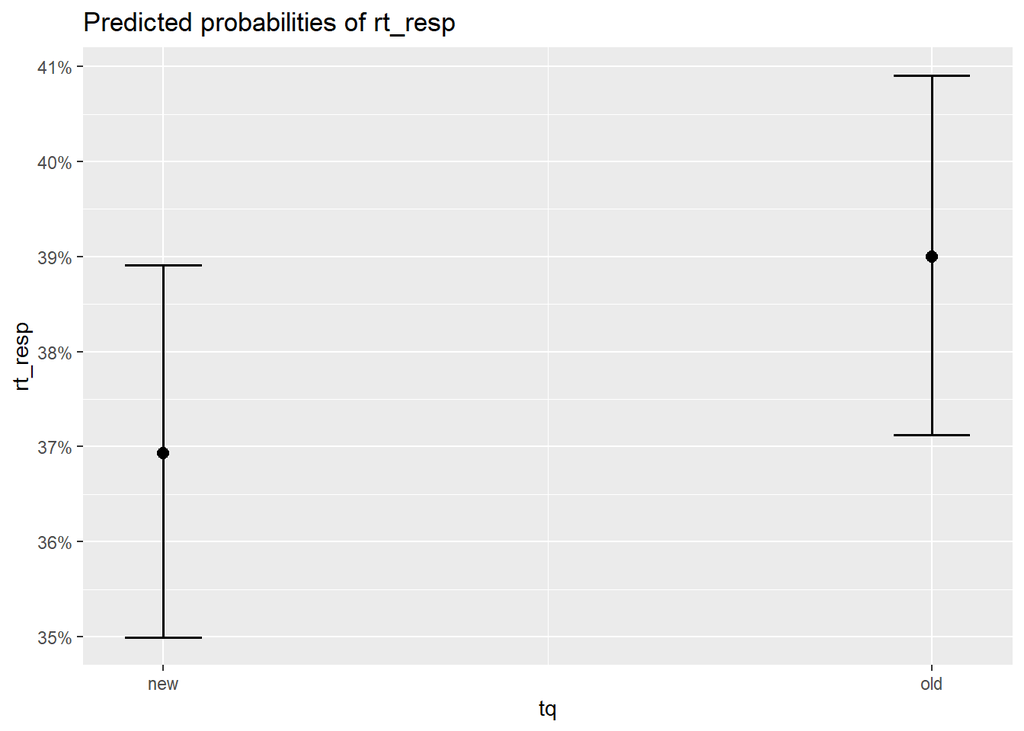

```
## Data were 'prettified'. Consider using `terms="DTAN [all]"` to get smooth plots.
```

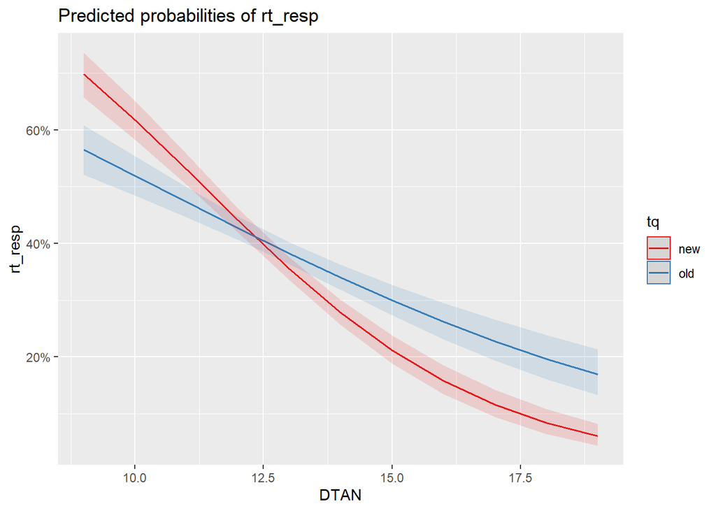

|  | rt_resp |  |  |  | rt_resp |  |  |  | rt_resp |  |  |  |
| --- | --- | --- | --- | --- | --- | --- | --- | --- | --- | --- | --- | --- |
| Predictors | Log-Odds | std. Error | CI | p | Log-Odds | std. Error | CI | p | Log-Odds | std. Error | CI | p |
| (Intercept) | 0.56 | 0.08 | 0.41 – 0.71 | **<0.001** | 3.06 | 0.24 | 2.60 – 3.52 | **<0.001** | 4.06 | 0.31 | 3.45 – 4.68 | **<0.001** |
| DTF | -0.16 | 0.01 | -0.18 – -0.14 | **<0.001** |  |  |  |  |  |  |  |  |
| tq [old] | -0.55 | 0.10 | -0.75 – -0.35 | **<0.001** | -1.83 | 0.31 | -2.43 – -1.23 | **<0.001** | -2.13 | 0.42 | -2.96 – -1.31 | **<0.001** |
| DTF * tq [old] | 0.09 | 0.01 | 0.07 – 0.12 | **<0.001** |  |  |  |  |  |  |  |  |
| DTAF |  |  |  |  | -0.28 | 0.02 | -0.32 – -0.24 | **<0.001** |  |  |  |  |
| DTAF * tq [old] |  |  |  |  | 0.15 | 0.02 | 0.10 – 0.20 | **<0.001** |  |  |  |  |
| DTAN |  |  |  |  |  |  |  |  | -0.36 | 0.02 | -0.41 – -0.31 | **<0.001** |
| DTAN * tq [old] |  |  |  |  |  |  |  |  | 0.17 | 0.03 | 0.11 – 0.24 | **<0.001** |
| Random Effects |  |  |  |  |  |  |  |  |  |  |  |  |
| σ<sup>2</sup> | 3.29 |  |  |  | 3.29 |  |  |  | 3.29 |  |  |  |
| τ<sub>00</sub> | 0.00 <sub>ID</sub> |  |  |  | 0.00 <sub>ID</sub> |  |  |  | 0.00 <sub>ID</sub> |  |  |  |
| N | 61 <sub>ID</sub> |  |  |  | 61 <sub>ID</sub> |  |  |  | 61 <sub>ID</sub> |  |  |  |
| Observations | 5261 |  |  |  | 5261 |  |  |  | 5261 |  |  |  |
| Marginal R<sup>2</sup> / Conditional R<sup>2</sup> | 0.118 / NA |  |  |  | 0.114 / NA |  |  |  | 0.085 / NA |  |  |  |
| AIC | 6674.364 |  |  |  | 6667.254 |  |  |  | 6722.976 |  |  |  |
| AICc | 6674.376 |  |  |  | 6667.266 |  |  |  | 6722.988 |  |  |  |